# 计算机视觉实践 第4次课，作者：邓擎琼

```python
'''得到所有选项圆圈'''
choiceCnts = []
# 遍历
for cnt in contours:
	# 包围盒
    x, y, w, h = cv2.boundingRect(cnt)
	# 根据实际情况指定标准
    if w >= 30 and h >= 30:
        choiceCnts.append([cnt, (x,y,w,h)])

print(len(choiceCnts))

for cnt,(x,y,w,h) in choiceCnts:
    print(x,y)
```

```
25
249 197
201 197
152 197
101 197
50 197
249 149
201 149
152 149
101 149
50 149
249 102
201 102
151 102
101 102
50 102
249 53
201 53
151 53
100 53
49 53
249 7
201 7
151 7
100 7
49 7
```

```python
choiceCnts.reverse()  #从上往下

questions=[]
for i in range(len(choiceCnts)//5):
    question = choiceCnts[i*5:i*5+5]  #每次取5个
    question.sort(key = lambda b: b[1][0])  #根据x坐标排序
    questions.append(question)
    for cnt,(x,y,w,h) in question:
        print(x,y)
```

```
49 7
100 7
151 7
201 7
249 7
49 53
100 53
151 53
201 53
249 53
50 102
101 102
151 102
201 102
249 102
50 149
101 149
152 149
201 149
249 149
50 197
101 197
152 197
201 197
249 197
```

```python
'''可视化排序结果'''
sortedQuestion = choices.copy()
sortedQuestion = cv2.cvtColor(sortedQuestion, cv2.COLOR_GRAY2BGR)
for one in questions:
    for cnt, (x,y,w,h) in one:
        cv2.drawContours(sortedQuestion, [cnt], -1, (0,0,255), 2)
        cv_show('sortedQuestion',sortedQuestion)
```

```
0
1
3
4
80
标准答案：[[0], [1], [2, 4], [0, 2], [3]]
学生答案：[[0], [1], [1, 2], [0, 2], [3]]
```

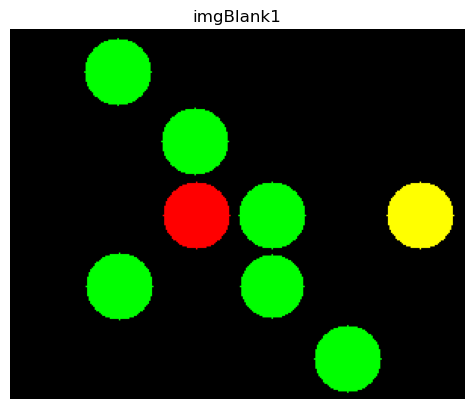

```python
'''根据给定的标准答案进行判题'''
#标准答案
answersGiven = [[0], [1], [2, 4], [0, 2], [3]]

imgBlank1 = np.zeros((choices.shape[0],choices.shape[1],3), dtype='uint8')
answers=[]
score = 0
for i, one in enumerate(questions): #对每道题
    oneAnsw = []
    for j, [cnt, (x,y,w,h)] in enumerate(one): #对每一个选项
        imgChoice = choices[y:y+h,x:x+w]
        nonZeroNum = cv2.countNonZero(imgChoice)
        if nonZeroNum/(w*h)>=0.4:  #涂抹了该选项
            oneAnsw.append(j)
            if j in answersGiven[i]: #选对，绿色
                cv2.circle(imgBlank1,(x+w//2,y+h//2), w//2, (0,255,0), -1)
            else:  #选错，红色
                cv2.circle(imgBlank1,(x+w//2,y+h//2), w//2, (0,0,255), -1)
        else: #未选，黄色
            if j in answersGiven[i]:
                cv2.circle(imgBlank1,(x+w//2,y+h//2), w//2, (0,255,255), -1)

    answers.append(oneAnsw)
    if answersGiven[i] ==  oneAnsw: #正确答题加分
        print(i)
        score += 20
print(score)
print(f'标准答案：{answersGiven}')
print(f'学生答案：{answers}')

plt_show('imgBlank1', imgBlank1)
```

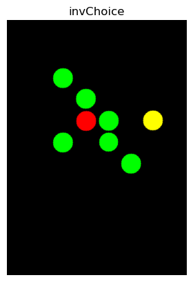

```python
'''把imgBlank1逆变回paper'''
def invPerspectiveTransform(pntsOrded, imgSrc, imgDst):
    height,width = imgSrc.shape[:2]

    # 变换前对应坐标位置
    src = np.array([
        [0, 0],
        [width - 1, 0],
        [width - 1, height - 1],
        [0, height - 1]], dtype="float32")

    heightDst,widthDst = imgDst.shape[:2]
    # 计算变换矩阵并进行变换
    M = cv2.getPerspectiveTransform(src, pntsOrded)
    warped = cv2.warpPerspective(imgSrc, M, (widthDst, heightDst))
    return warped

invChoice = invPerspectiveTransform(rect1Orded, imgBlank1, paper)
plt_show('invChoice', invChoice)
```

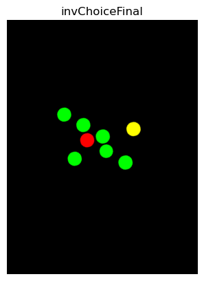

```python
'''再进一步把invChoice逆变回img'''
invChoiceFinal = invPerspectiveTransform(pntsOrded, invChoice, img)
plt_show('invChoiceFinal', invChoiceFinal)
```

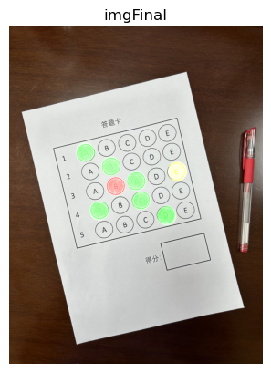

```python
'''逆变换回来的图像和原图相加'''
imgFinal = img.copy()
imgFinal = cv2.add(imgFinal, invChoiceFinal)
plt_show('imgFinal', imgFinal)
```

[output not shown]

[figure not shown]

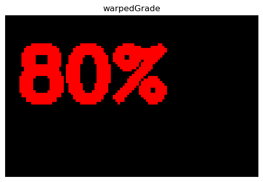

```python
'''绘制得分'''
rect2Orded = orderPoints(rect2.reshape((-1,2))) #得分对应的长方形轮廓
warpedGrade = perspectiveTransform(rect2Orded, paper)

imgBlank2 = np.zeros_like(warpedGrade)
cv2.putText(imgBlank2,str(int(score))+"%",(5,35)
                        ,cv2.FONT_HERSHEY_COMPLEX,1,(0,0,255),3)

plt_show('warpedGrade', imgBlank2)
```

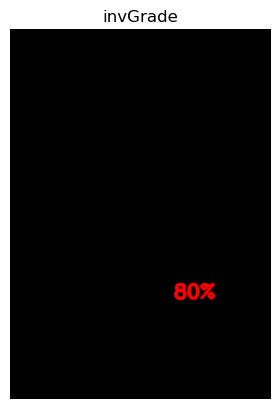

```python
'''同理，把分数逆变换至paper'''
invGrade = invPerspectiveTransform(rect2Orded, imgBlank2, paper)
plt_show('invGrade', invGrade)
```

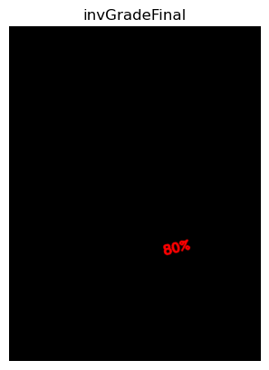

```python
invGradeFinal = invPerspectiveTransform(pntsOrded, invGrade, img)
plt_show('invGradeFinal', invGradeFinal)
```

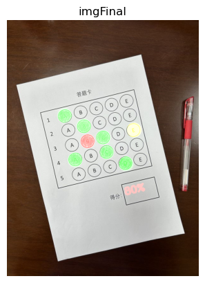

```python
imgFinal = cv2.add(imgFinal, invGradeFinal) #和原图叠加
plt_show('imgFinal', imgFinal)
```

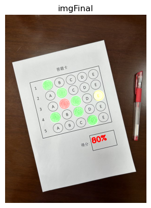

```python
'''通过前景背景融合让分数显示更清楚一点'''
ret, mask = cv2.threshold(cv2.cvtColor(invGradeFinal, cv2.COLOR_BGR2GRAY), 50, 255, cv2.THRESH_BINARY)
mask_inv = cv2.bitwise_not(mask)

background = cv2.bitwise_and(imgFinal, imgFinal, mask = mask_inv)
foreground = cv2.bitwise_and(invGradeFinal, invGradeFinal, mask = mask)
imgFinal = cv2.add(foreground, background)
plt_show('imgFinal', imgFinal)
```

#### 完整代码实现：

```python
import cv2
import numpy as np
answersGiven = [[0],[1],[2,4],[0,2],[3]]
def orderPoints(pts):  # 对4点进行排序
    # 共4个坐标点
    rect = np.zeros((4, 2), dtype="float32")
    # 按顺序找到对应坐标0、1、2、3分别是左上、右上、右下、左下
    # 计算左上和右下
    s = pts.sum(axis=1)
    rect[0] = pts[np.argmin(s)]
    rect[2] = pts[np.argmax(s)]
    # 计算右上和左下
    diff = np.diff(pts, axis=1)
    rect[1] = pts[np.argmin(diff)]
    rect[3] = pts[np.argmax(diff)]
    return rect

#透视变换
def perspectiveTransform(pntsOrded, img):
    tl, tr, br, bl = pntsOrded
    # 计算输入的w和h值
    widthA = np.sqrt(((br[0] - bl[0]) ** 2) + ((br[1] - bl[1]) ** 2))
    widthB = np.sqrt(((tr[0] - tl[0]) ** 2) + ((tr[1] - tl[1]) ** 2))
    maxWidth = max(int(widthA), int(widthB))

    heightA = np.sqrt(((tr[0] - br[0]) ** 2) + ((tr[1] - br[1]) ** 2))
    heightB = np.sqrt(((tl[0] - bl[0]) ** 2) + ((tl[1] - bl[1]) ** 2))
    maxHeight = max(int(heightA), int(heightB))

    # 变换后对应坐标位置
    dst = np.array([
        [0, 0],
        [maxWidth - 1, 0],
        [maxWidth - 1, maxHeight - 1],
        [0, maxHeight - 1]], dtype="float32")

    # 计算变换矩阵
    M = cv2.getPerspectiveTransform(pntsOrded, dst)
    warped = cv2.warpPerspective(img, M, (maxWidth, maxHeight))
    return warped

#透视逆变换
def invPerspectiveTransform(pntsOrded, imgSrc, imgDst):
    height,width = imgSrc.shape[:2]

    # 变换前对应坐标位置
    src = np.array([
        [0, 0],
        [width - 1, 0],
        [width - 1, height - 1],
        [0, height - 1]], dtype="float32")

    heightDst,widthDst = imgDst.shape[:2]
    # 计算变换矩阵并进行变换
    M = cv2.getPerspectiveTransform(src, pntsOrded)
    warped = cv2.warpPerspective(imgSrc, M, (widthDst, heightDst))
    return warped

#获得轮廓并随机颜色显示每条轮廓
def findShowContours(imgCont, imgShow):
    contours, hier = cv2.findContours(imgCont, cv2.RETR_EXTERNAL, cv2.CHAIN_APPROX_SIMPLE)
    print('轮廓数量：', len(contours))

    imgContours = imgShow.copy()
    for i in range(len(contours)):
        cv2.drawContours(imgContours, contours, i, (np.random.randint(0,255), np.random.randint(0,255), np.random.randint(0,255)), 2)
    cv_show('Contours',imgContours)
    return contours

img = cv2.imread("Images/1.jpg")
cv2.imshow('Original Image', img)

imgGray = cv2.cvtColor(img, cv2.COLOR_BGR2GRAY)
imgBlur = cv2.GaussianBlur(imgGray, (3, 3), 1)

#阈值，得到答题卡区域
ret1, thresh1 = cv2.threshold(imgBlur, 180, 255, cv2.THRESH_BINARY)
cv2.imshow('thresh1', thresh1)

contours = findShowContours(thresh1, img)

#最大轮廓是答题卡纸的轮廓
cnt = contours[0]
maxArea = cv2.contourArea(cnt)
maxCntId = 0
for i, cnt in enumerate(contours[1:], 1):
    area = cv2.contourArea(cnt)
    if area>maxArea:
        maxArea = area
        maxCntId = i

arc = cv2.arcLength(contours[maxCntId], True)
approx = cv2.approxPolyDP(contours[maxCntId], 0.1 * arc, True)
imgContours = img.copy()
cv2.drawContours(imgContours, [approx], -1, (0,0,255), 2)
cv2.imshow('Contours',imgContours)

#透视变换
pntsOrded = orderPoints(approx.reshape((4,2)))
paper = perspectiveTransform(pntsOrded, img)
paperThresh = perspectiveTransform(pntsOrded, thresh1)


paperThreshInv = cv2.bitwise_not(paperThresh)
cv2.imshow('paperThreshInv', paperThreshInv)

contours = findShowContours(paperThreshInv, paper)

#筛选出两个正方形轮廓，一个对应答题区，一个对应分数区
rectCon = []
for cnt in contours:
    area = cv2.contourArea(cnt)
    if area > 80:
        arc = cv2.arcLength(cnt, True)
        approx = cv2.approxPolyDP(cnt, 0.02 * arc, True)
        if len(approx)==4:
            rectCon.append(approx)

rectCon.sort(key=cv2.contourArea,reverse=True)

rect1 = np.array(rectCon[0]).reshape(-1,1,2)  #答题区
rect2 = np.array(rectCon[1]).reshape(-1,1,2)  #分数区

#对答题区透视变换
rect1Orded = orderPoints(rect1.reshape((-1,2)))
choices = perspectiveTransform(rect1Orded, paperThreshInv)[3:-3,3:-3]
ret, choices = cv2.threshold(choices, 100, 255, cv2.THRESH_BINARY)

rect1Contours = choices.copy()
rect1Contours = cv2.cvtColor(rect1Contours, cv2.COLOR_GRAY2BGR)
contours = findShowContours(choices, rect1Contours)

choiceCnts = []
# 遍历
for cnt in contours:
	# 包围盒
    x, y, w, h = cv2.boundingRect(cnt)
	# 根据实际情况指定标准，得到答题区的每一个圆形轮廓，即选项
    if w >= 30 and h >= 30:
        choiceCnts.append([cnt, (x,y,w,h)])

choiceCnts.reverse()
#排序，按顺序得到每一道题的选项
questions=[]
for i in range(len(choiceCnts)//5):
    question = choiceCnts[i*5:i*5+5]
    question.sort(key = lambda b: b[1][0])
    questions.append(question)

print(choices.shape)
imgBlank1 = np.zeros((choices.shape[0],choices.shape[1],3), dtype='uint8')
answers=[]
score = 0
for j, one in enumerate(questions):
    oneAnsw = []  #当前题目的答题情况
    for i, [cnt, (x,y,w,h)] in enumerate(one):
        imgChoice = choices[y:y+h,x:x+w]
        nonZeroNum = cv2.countNonZero(imgChoice)
        if nonZeroNum/(w*h)>=0.4: #填涂面积比例大于0.5，则认为是选中该项
            oneAnsw.append(i)
            if i in answersGiven[j]:  #选对，绿色
                cv2.circle(imgBlank1,(x+w//2,y+h//2), w//2, (0,255,0), -1)
            else:   #选错，红色
                cv2.circle(imgBlank1,(x+w//2,y+h//2), w//2, (0,0,255), -1)
        else: #未选，黄色
            if i in answersGiven[j]:
                cv2.circle(imgBlank1,(x+w//2,y+h//2), w//2, (0,255,255), -1)

    answers.append(oneAnsw)
    if answersGiven[j] ==  oneAnsw:  #整道题正确则加分
        print(j)
        score += 20
print(score)
print(answersGiven)
print(answers)

#逆变换回去显示答题情况
cv2.imshow('imgBlank1', imgBlank1)
invChoice = invPerspectiveTransform(rect1Orded, imgBlank1, paper)
invChoiceFinal = invPerspectiveTransform(pntsOrded, invChoice, img)

imgFinal = img.copy()
imgFinal = cv2.add(imgFinal, invChoiceFinal)

#分数逆变换回去并显示
rect2Orded = orderPoints(rect2.reshape((-1,2)))
warpedGrade = perspectiveTransform(rect2Orded, paper)

imgBlank2 = np.zeros_like(warpedGrade)
cv2.putText(imgBlank2,str(int(score))+"%",(5,35)
                        ,cv2.FONT_HERSHEY_COMPLEX,1,(0,0,255),3)

invGrade = invPerspectiveTransform(rect2Orded, imgBlank2, paper)
invGradeFinal = invPerspectiveTransform(pntsOrded, invGrade, img)

invGradeFinalGray = cv2.cvtColor(invGradeFinal, cv2.COLOR_BGR2GRAY)
ret, mask = cv2.threshold(invGradeFinalGray, 50, 255, cv2.THRESH_BINARY)
mask_inv = cv2.bitwise_not(mask)


background = cv2.bitwise_and(imgFinal, imgFinal, mask = mask_inv)
foreground = cv2.bitwise_and(invGradeFinal, invGradeFinal, mask = mask)
imgFinal = cv2.add(foreground, background)
cv_show('imgFinal', imgFinal)
```

```
轮廓数量： 13
轮廓数量： 178
轮廓数量： 137
(245, 301)
0
1
3
4
80
[[0], [1], [2, 4], [0, 2], [3]]
[[0], [1], [1, 2], [0, 2], [3]]
```

**思考：是否可以借鉴答题卡选择题判卷土方法？**

[video not shown]

标准答案模板：

[figure not shown]

借鉴土方法的思路：

[figure not shown]

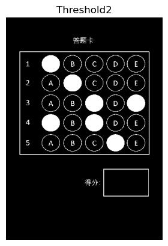

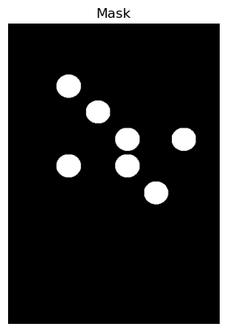

```python
'''读入标准答案图像，得到mask'''
img2 = cv2.imread('Images/Standard.png', 0)  #以灰度图模式读入
img2 = cv2.resize(img2, (paperThreshInv.shape[1], paperThreshInv.shape[0]))

ret, threshold2 = cv2.threshold(img2,150,255,cv2.THRESH_BINARY_INV)
plt_show('Threshold2', threshold2)

#形态学操作
kernel = cv2.getStructuringElement(cv2.MORPH_RECT, (5,5))
mask = cv2.morphologyEx(threshold2, cv2.MORPH_OPEN, kernel,iterations = 2)

plt_show('Mask', mask)
```

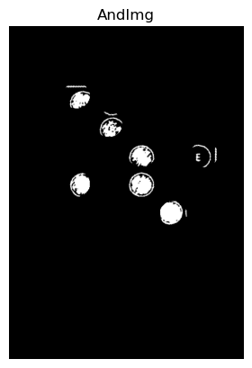

```python
andImg = cv2.bitwise_and(mask, paperThreshInv)

plt_show('AndImg', andImg)
```

**基本认知：所有光学相机镜头都存在畸变的问题。**另外还可能有别的误差，例如打印时纸张位置有偏差。

## 作业：

首先完成计算机视觉知识测试试卷，然后编写一个对测试结果进行自动判分的程序，能够对摄像头中出现的答题卡进行自动判分，并把所判试卷的学号和成绩保存到一个CSV文件。